# ViewCastLK: simple EDA of every input

## Inside each category

One page per category. Each small chart is one input a creator controls, and **1× is now the typical video in that category**, not across all videos. So the chart answers: within Comedy (say), do Shorts, longer videos or evening posts do better? The orange diamond again compares each video with its own channel. The table under each page lists the best and worst value of every input.

### News & Politics

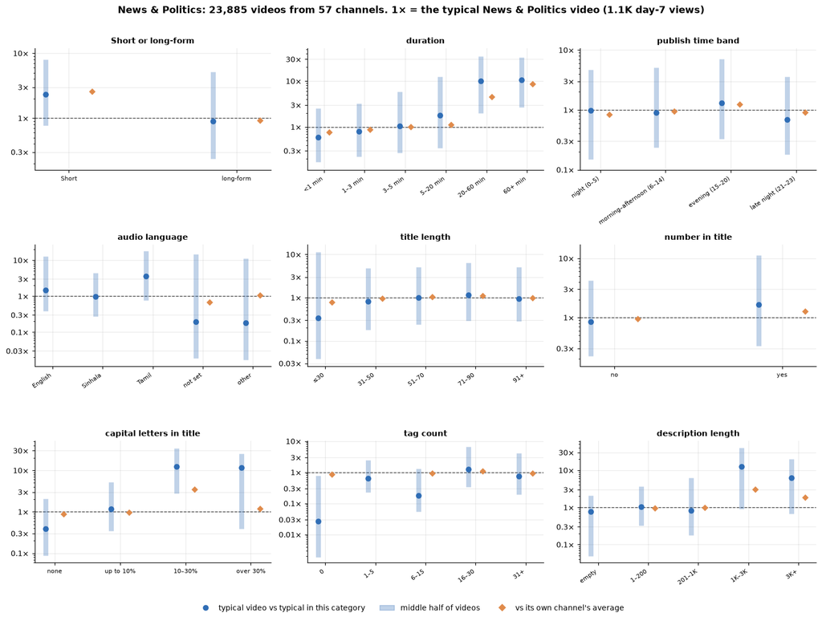

| input | best (vs typical in category) | worst | best vs own channel | worst vs own channel | own-channel gap |
| --- | --- | --- | --- | --- | --- |
| Short or long-form | Short (2.3×) | long-form (0.90×) | Short (2.6×) | long-form (0.92×) | 2.79× |
| duration | 60+ min (11×) | <1 min (0.59×) | 60+ min (8.5×) | <1 min (0.76×) | 11.20× |
| publish time band | evening (15–20) (1.31×) | late night (21–23) (0.69×) | evening (15–20) (1.22×) | night (0–5) (0.82×) | 1.49× |
| audio language | Tamil (3.5×) | other (0.18×) | other (1.03×) | not set (0.66×) | 1.56× |
| title length | 71–90 (1.14×) | ≤30 (0.34×) | 71–90 (1.10×) | ≤30 (0.78×) | 1.41× |
| number in title | yes (1.66×) | no (0.86×) | yes (1.26×) | no (0.93×) | 1.34× |
| capital letters in title | 10–30% (12×) | none (0.39×) | 10–30% (3.4×) | none (0.87×) | 3.96× |
| tag count | 16–30 (1.26×) | 0 (0.03×) | 16–30 (1.08×) | 6–15 (0.91×) | 1.19× |
| description length | 1K–3K (13×) | empty (0.77×) | 1K–3K (3.0×) | 1–200 (0.93×) | 3.20× |

**How to read these pages.** Inside a category, the **blue dots can still mislead**: a handful of big channels decide most raw values (for example a single high-volume channel that never uses tags). The **orange diamond** is the reliable one, and the "vs own channel" columns in the table are the numbers to quote.

**News & Politics.** Against their own channel, News videos do better when they are Shorts (2.6×), long (60+ minutes, 8.5×), posted in the evening (1.2×), have a number in the title (1.3×) and have some capitals or a long description. These are the channel's *unusual* videos: most News channels post 2 to 5 minute clips, so the few streams and Shorts stand out. Tags make little difference.

### Education

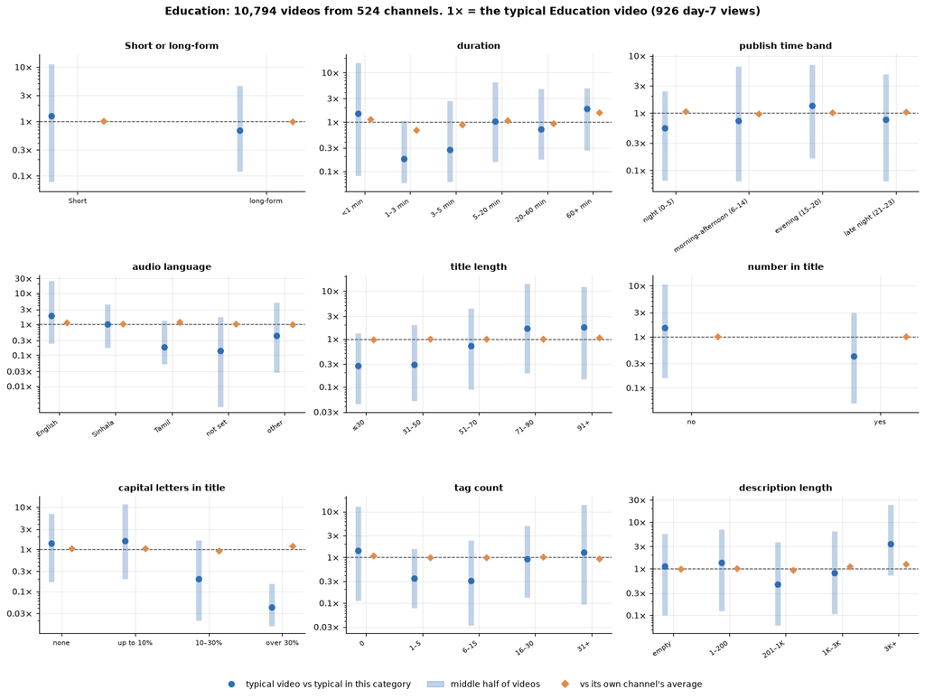

| input | best (vs typical in category) | worst | best vs own channel | worst vs own channel | own-channel gap |
| --- | --- | --- | --- | --- | --- |
| Short or long-form | Short (1.28×) | long-form (0.68×) | Short (1.01×) | long-form (0.98×) | 1.03× |
| duration | 60+ min (1.84×) | 1–3 min (0.18×) | 60+ min (1.54×) | 1–3 min (0.67×) | 2.29× |
| publish time band | evening (15–20) (1.34×) | night (0–5) (0.54×) | night (0–5) (1.06×) | morning–afternoon (6–14) (0.97×) | 1.09× |
| audio language | English (1.92×) | not set (0.14×) | Tamil (1.16×) | other (0.97×) | 1.19× |
| title length | 91+ (1.77×) | ≤30 (0.27×) | 91+ (1.04×) | ≤30 (0.97×) | 1.08× |
| number in title | no (1.50×) | yes (0.42×) | no (1.01×) | yes (0.99×) | 1.02× |
| capital letters in title | up to 10% (1.56×) | over 30% (0.04×) | over 30% (1.19×) | 10–30% (0.91×) | 1.31× |
| tag count | 0 (1.41×) | 6–15 (0.30×) | 0 (1.06×) | 31+ (0.92×) | 1.16× |
| description length | 3K+ (3.5×) | 201–1K (0.47×) | 3K+ (1.24×) | 201–1K (0.91×) | 1.37× |

**Education.** Most inputs make little difference within a channel. The exceptions are **length** (60+ minute videos 1.5× the channel's average, 1 to 3 minutes 0.7×) and a **long description** (3K+ characters, 1.2×). Shorts against long-form: no difference.

### Entertainment

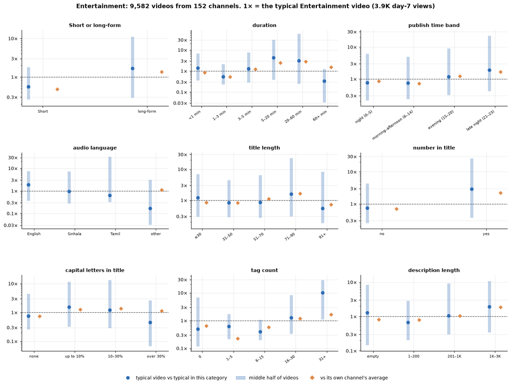

| input | best (vs typical in category) | worst | best vs own channel | worst vs own channel | own-channel gap |
| --- | --- | --- | --- | --- | --- |
| Short or long-form | long-form (1.67×) | Short (0.56×) | long-form (1.34×) | Short (0.48×) | 2.79× |
| duration | 5–20 min (4.3×) | 60+ min (0.33×) | 20–60 min (2.8×) | 1–3 min (0.51×) | 5.52× |
| publish time band | late night (21–23) (1.92×) | morning–afternoon (6–14) (0.75×) | late night (21–23) (1.67×) | morning–afternoon (6–14) (0.71×) | 2.34× |
| audio language | English (1.88×) | other (0.17×) | too few channels |  |  |
| title length | 71–90 (1.60×) | 91+ (0.55×) | 71–90 (1.62×) | 91+ (0.73×) | 2.24× |
| number in title | yes (2.9×) | no (0.75×) | yes (2.2×) | no (0.69×) | 3.19× |
| capital letters in title | up to 10% (1.54×) | over 30% (0.46×) | 10–30% (1.34×) | none (0.74×) | 1.82× |
| tag count | 31+ (10×) | 6–15 (0.40×) | 31+ (1.63×) | 1–5 (0.23×) | 7.25× |
| description length | 1K–3K (1.92×) | 1–200 (0.67×) | 1K–3K (1.83×) | 1–200 (0.79×) | 2.32× |

**Entertainment.** The category where creator choices matter most, and the one that goes **against** the general Shorts advice: **long-form beats Shorts** (1.3× against 0.5× the channel's average). Also better: 5 to 60 minute videos, **late-night posting** (21:00 to 23:00, 1.7×), a **number in the title** (2.2×, usually episode numbers), 71 to 90 character titles, **31+ tags** (1.6×; 1 to 5 tags 0.2×) and descriptions of 1K to 3K characters.

### Travel & Events

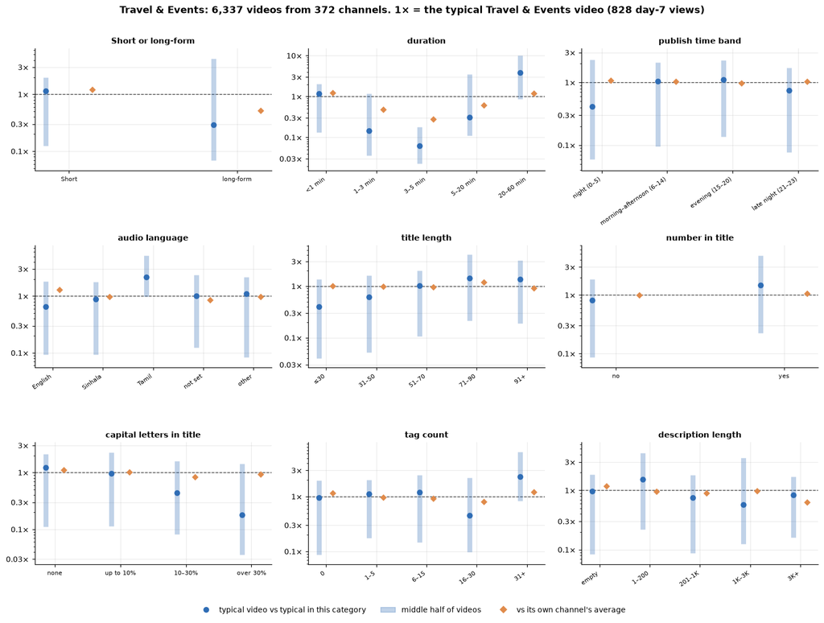

| input | best (vs typical in category) | worst | best vs own channel | worst vs own channel | own-channel gap |
| --- | --- | --- | --- | --- | --- |
| Short or long-form | Short (1.14×) | long-form (0.29×) | Short (1.21×) | long-form (0.51×) | 2.38× |
| duration | 20–60 min (3.8×) | 3–5 min (0.06×) | <1 min (1.22×) | 3–5 min (0.28×) | 4.42× |
| publish time band | evening (15–20) (1.12×) | night (0–5) (0.41×) | night (0–5) (1.07×) | evening (15–20) (0.97×) | 1.10× |
| audio language | Tamil (2.2×) | English (0.65×) | English (1.28×) | not set (0.84×) | 1.51× |
| title length | 71–90 (1.42×) | ≤30 (0.40×) | 71–90 (1.19×) | 91+ (0.90×) | 1.33× |
| number in title | yes (1.46×) | no (0.82×) | yes (1.05×) | no (0.99×) | 1.06× |
| capital letters in title | none (1.23×) | 10–30% (0.44×) | none (1.10×) | 10–30% (0.83×) | 1.32× |
| tag count | 31+ (2.3×) | 16–30 (0.46×) | 31+ (1.21×) | 16–30 (0.79×) | 1.53× |
| description length | 1–200 (1.53×) | 1K–3K (0.57×) | empty (1.16×) | 3K+ (0.63×) | 1.85× |

**Travel & Events.** **Shorts** beat long-form (1.2× against 0.5×), and 3 to 5 minute videos do very badly (0.3×). English audio (1.3×), many tags (31+, 1.2×) and a short or empty description do better. Time of day does not matter.

### Music

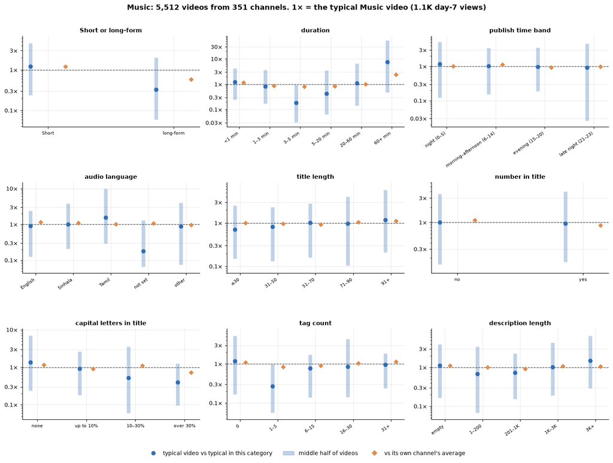

| input | best (vs typical in category) | worst | best vs own channel | worst vs own channel | own-channel gap |
| --- | --- | --- | --- | --- | --- |
| Short or long-form | Short (1.22×) | long-form (0.33×) | Short (1.20×) | long-form (0.57×) | 2.09× |
| duration | <1 min (1.22×) | 3–5 min (0.19×) | <1 min (1.16×) | 3–5 min (0.81×) | 1.44× |
| publish time band | night (0–5) (1.19×) | late night (21–23) (0.93×) | morning–afternoon (6–14) (1.12×) | evening (15–20) (0.94×) | 1.20× |
| audio language | Tamil (1.56×) | other (0.89×) | English (1.14×) | other (0.96×) | 1.19× |
| title length | 91+ (1.19×) | ≤30 (0.71×) | 91+ (1.11×) | 51–70 (0.91×) | 1.22× |
| number in title | no (1.01×) | yes (0.94×) | no (1.10×) | yes (0.86×) | 1.27× |
| capital letters in title | none (1.35×) | over 30% (0.40×) | none (1.15×) | over 30% (0.71×) | 1.61× |
| tag count | 0 (1.18×) | 1–5 (0.27×) | 31+ (1.13×) | 1–5 (0.84×) | 1.35× |
| description length | 3K+ (1.50×) | 1–200 (0.68×) | empty (1.11×) | 201–1K (0.91×) | 1.22× |

**Music.** **Shorts** beat long-form (1.2× against 0.6×). Titles **without capitals** do best and titles over 30% capitals worst (0.7×). A number in the title slightly hurts. Time of day makes little difference.

### People & Blogs

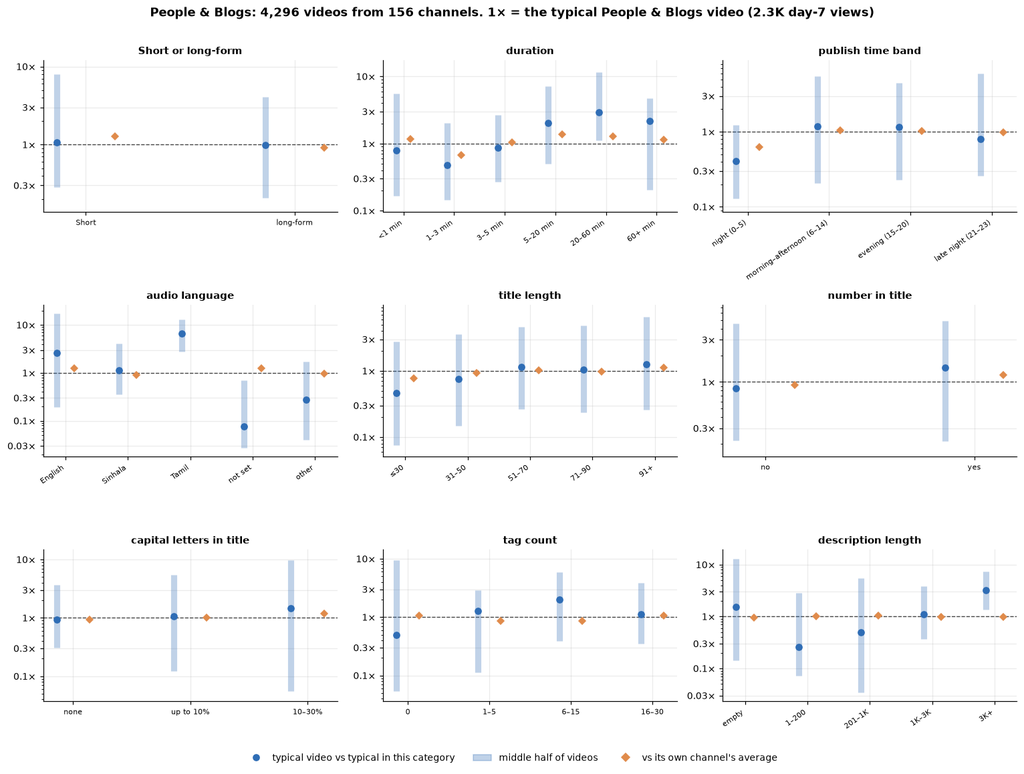

| input | best (vs typical in category) | worst | best vs own channel | worst vs own channel | own-channel gap |
| --- | --- | --- | --- | --- | --- |
| Short or long-form | Short (1.06×) | long-form (0.98×) | Short (1.27×) | long-form (0.91×) | 1.39× |
| duration | 20–60 min (2.9×) | 1–3 min (0.47×) | 5–20 min (1.36×) | 1–3 min (0.67×) | 2.02× |
| publish time band | morning–afternoon (6–14) (1.19×) | night (0–5) (0.41×) | morning–afternoon (6–14) (1.05×) | night (0–5) (0.63×) | 1.67× |
| audio language | Tamil (6.7×) | other (0.27×) | English (1.23×) | other (0.96×) | 1.28× |
| title length | 91+ (1.26×) | ≤30 (0.47×) | 91+ (1.12×) | ≤30 (0.77×) | 1.46× |
| number in title | yes (1.45×) | no (0.85×) | yes (1.21×) | no (0.92×) | 1.32× |
| capital letters in title | 10–30% (1.47×) | none (0.93×) | 10–30% (1.17×) | none (0.92×) | 1.27× |
| tag count | 6–15 (1.98×) | 0 (0.50×) | 0 (1.06×) | 1–5 (0.87×) | 1.23× |
| description length | empty (1.54×) | 1–200 (0.26×) | 201–1K (1.03×) | empty (0.95×) | 1.08× |

**People & Blogs.** Shorts do a little better (1.3× against 0.9×) and 5 to 20 minute videos best among long-form. **Avoid posting at night** (0:00 to 5:00, 0.6×). Longer titles and a number in the title help slightly.

### Gaming

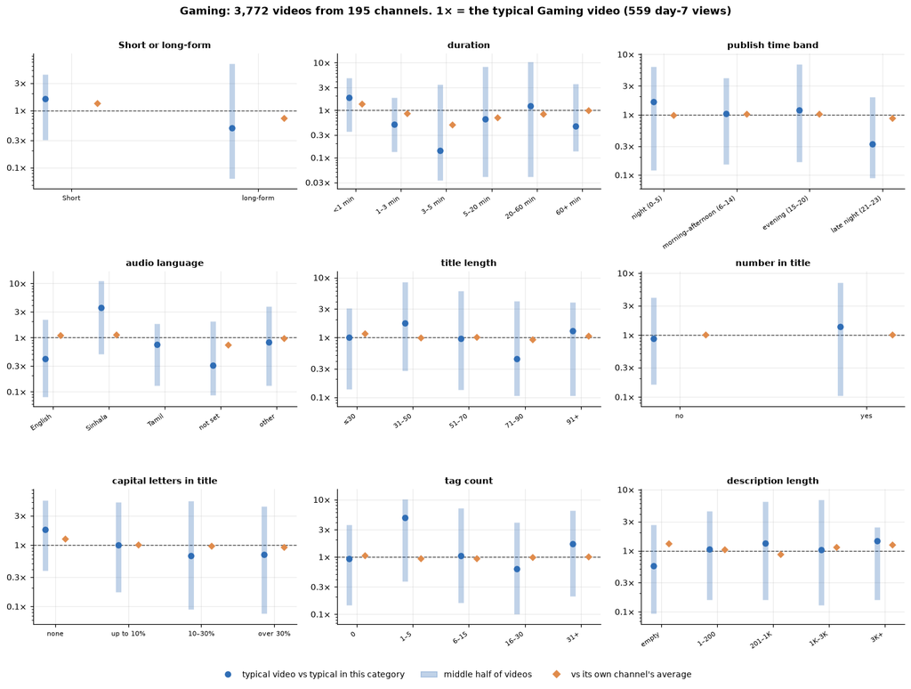

| input | best (vs typical in category) | worst | best vs own channel | worst vs own channel | own-channel gap |
| --- | --- | --- | --- | --- | --- |
| Short or long-form | Short (1.62×) | long-form (0.49×) | Short (1.31×) | long-form (0.73×) | 1.79× |
| duration | <1 min (1.82×) | 3–5 min (0.14×) | <1 min (1.33×) | 5–20 min (0.70×) | 1.90× |
| publish time band | night (0–5) (1.62×) | late night (21–23) (0.33×) | evening (15–20) (1.02×) | late night (21–23) (0.87×) | 1.17× |
| audio language | Sinhala (3.6×) | English (0.41×) | Sinhala (1.11×) | other (0.96×) | 1.15× |
| title length | 31–50 (1.74×) | 71–90 (0.44×) | ≤30 (1.15×) | 71–90 (0.91×) | 1.26× |
| number in title | yes (1.38×) | no (0.89×) | no (1.01×) | yes (1.00×) | 1.01× |
| capital letters in title | none (1.79×) | 10–30% (0.68×) | none (1.25×) | over 30% (0.92×) | 1.35× |
| tag count | 1–5 (4.8×) | 16–30 (0.61×) | 0 (1.05×) | 1–5 (0.93×) | 1.13× |
| description length | 3K+ (1.45×) | empty (0.57×) | empty (1.30×) | 201–1K (0.86×) | 1.50× |

**Gaming.** **Shorts** beat long-form (1.3× against 0.7×), and 5 to 20 minute videos do worst. Titles without capitals and an empty description do slightly better. Time of day and tags make little difference.

### Howto & Style

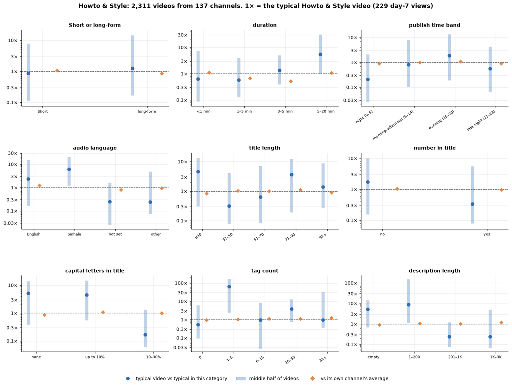

| input | best (vs typical in category) | worst | best vs own channel | worst vs own channel | own-channel gap |
| --- | --- | --- | --- | --- | --- |
| Short or long-form | long-form (1.26×) | Short (0.87×) | Short (1.05×) | long-form (0.85×) | 1.24× |
| duration | 5–20 min (5.5×) | 1–3 min (0.57×) | <1 min (1.10×) | 1–3 min (0.67×) | 1.64× |
| publish time band | evening (15–20) (1.85×) | late night (21–23) (0.57×) | evening (15–20) (1.07×) | late night (21–23) (0.90×) | 1.19× |
| audio language | Sinhala (6.1×) | other (0.24×) | English (1.19×) | other (0.95×) | 1.26× |
| title length | ≤30 (4.6×) | 31–50 (0.32×) | 71–90 (1.11×) | ≤30 (0.83×) | 1.34× |
| number in title | no (1.75×) | yes (0.33×) | no (1.02×) | yes (0.96×) | 1.07× |
| capital letters in title | none (5.2×) | 10–30% (0.17×) | up to 10% (1.08×) | none (0.87×) | 1.24× |
| tag count | 1–5 (64×) | 0 (0.54×) | 16–30 (1.10×) | 0 (0.92×) | 1.21× |
| description length | 1–200 (8.7×) | 1K–3K (0.24×) | 1K–3K (1.16×) | empty (0.89×) | 1.31× |

**Howto & Style.** Within a channel, most choices make little difference. Shorts do slightly better (1.05× against 0.85×) and 1 to 3 minute videos worst. The huge raw numbers on this page (for example 64× for 1 to 5 tags) come from one or two very large channels and should be ignored.

### Autos & Vehicles

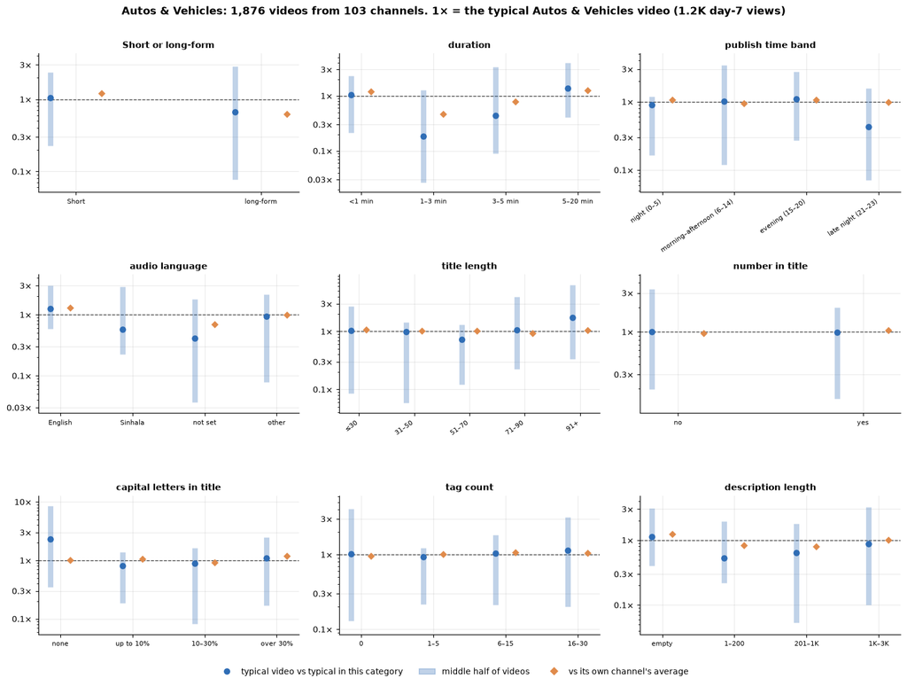

| input | best (vs typical in category) | worst | best vs own channel | worst vs own channel | own-channel gap |
| --- | --- | --- | --- | --- | --- |
| Short or long-form | Short (1.04×) | long-form (0.67×) | Short (1.21×) | long-form (0.62×) | 1.95× |
| duration | 5–20 min (1.37×) | 1–3 min (0.18×) | 5–20 min (1.24×) | 1–3 min (0.46×) | 2.67× |
| publish time band | evening (15–20) (1.09×) | late night (21–23) (0.43×) | night (0–5) (1.06×) | morning–afternoon (6–14) (0.94×) | 1.13× |
| audio language | English (1.26×) | Sinhala (0.57×) | English (1.28×) | other (0.98×) | 1.30× |
| title length | 91+ (1.73×) | 51–70 (0.74×) | ≤30 (1.07×) | 71–90 (0.92×) | 1.17× |
| number in title | no (1.01×) | yes (0.99×) | yes (1.04×) | no (0.95×) | 1.10× |
| capital letters in title | none (2.3×) | up to 10% (0.80×) | up to 10% (1.05×) | 10–30% (0.92×) | 1.15× |
| tag count | 16–30 (1.15×) | 1–5 (0.94×) | 6–15 (1.06×) | 0 (0.95×) | 1.11× |
| description length | empty (1.13×) | 1–200 (0.53×) | empty (1.24×) | 201–1K (0.79×) | 1.56× |

**Autos & Vehicles.** **Shorts** beat long-form (1.2× against 0.6×); among long-form, 5 to 20 minutes is best and 1 to 3 minutes worst (0.5×). English audio does better (1.3×). Time of day, title and tags make little difference.

### Sports

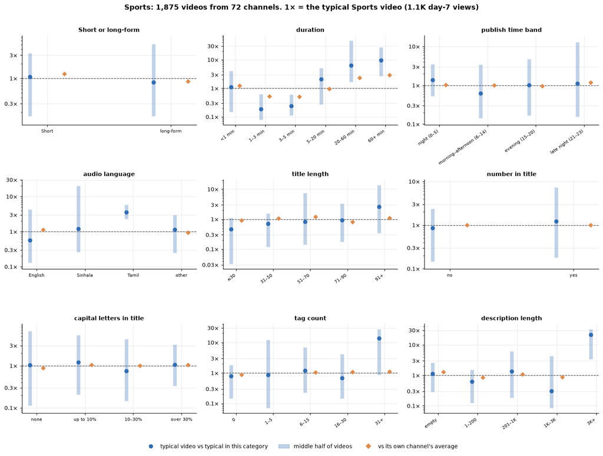

| input | best (vs typical in category) | worst | best vs own channel | worst vs own channel | own-channel gap |
| --- | --- | --- | --- | --- | --- |
| Short or long-form | Short (1.07×) | long-form (0.83×) | Short (1.24×) | long-form (0.86×) | 1.43× |
| duration | 60+ min (9.6×) | 1–3 min (0.19×) | 60+ min (2.9×) | 3–5 min (0.50×) | 5.86× |
| publish time band | night (0–5) (1.37×) | morning–afternoon (6–14) (0.62×) | late night (21–23) (1.16×) | evening (15–20) (0.94×) | 1.23× |
| audio language | Tamil (3.5×) | English (0.57×) | English (1.13×) | other (0.93×) | 1.21× |
| title length | 91+ (2.6×) | 31–50 (0.71×) | 51–70 (1.17×) | 71–90 (0.79×) | 1.48× |
| number in title | yes (1.21×) | no (0.85×) | yes (0.99×) | no (0.99×) | 1.00× |
| capital letters in title | up to 10% (1.21×) | 10–30% (0.76×) | over 30% (1.04×) | none (0.88×) | 1.19× |
| tag count | 31+ (14×) | 16–30 (0.69×) | 31+ (1.10×) | 0 (0.87×) | 1.26× |
| description length | 201–1K (1.36×) | 1K–3K (0.31×) | empty (1.29×) | 1–200 (0.83×) | 1.54× |

**Sports.** Long streams (**60+ minutes**, 2.9×, usually full matches) and **Shorts** (1.2× against 0.9×) both do well; 3 to 5 minute videos worst. Late-night posting helps a little, and so do weekends (section 10 grids).

### Comedy

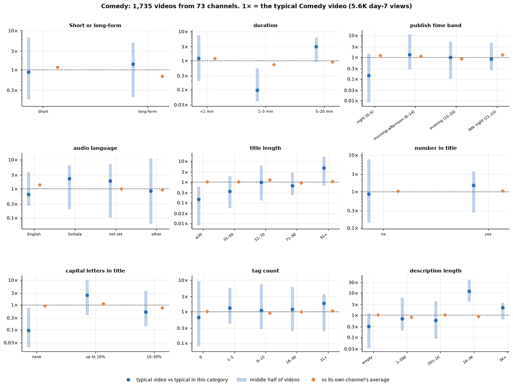

| input | best (vs typical in category) | worst | best vs own channel | worst vs own channel | own-channel gap |
| --- | --- | --- | --- | --- | --- |
| Short or long-form | long-form (1.41×) | Short (0.88×) | Short (1.15×) | long-form (0.68×) | 1.70× |
| duration | 5–20 min (3.0×) | 1–3 min (0.10×) | <1 min (1.15×) | 1–3 min (0.72×) | 1.59× |
| publish time band | morning–afternoon (6–14) (1.33×) | late night (21–23) (0.84×) | late night (21–23) (1.28×) | evening (15–20) (0.84×) | 1.52× |
| audio language | Sinhala (2.2×) | English (0.65×) | English (1.34×) | other (0.90×) | 1.49× |
| title length | 91+ (4.7×) | ≤30 (0.14×) | 51–70 (1.24×) | 71–90 (0.88×) | 1.41× |
| number in title | yes (1.49×) | no (0.86×) | yes (1.04×) | no (1.01×) | 1.02× |
| capital letters in title | up to 10% (2.5×) | none (0.09×) | up to 10% (1.10×) | 10–30% (0.76×) | 1.46× |
| tag count | 31+ (1.85×) | 0 (0.66×) | 31+ (1.04×) | 16–30 (0.96×) | 1.08× |
| description length | 1K–3K (12×) | empty (0.31×) | 201–1K (1.02×) | 1K–3K (0.86×) | 1.19× |

**Comedy.** **Shorts** beat long-form within a channel (1.15× against 0.7×), though the raw view says the opposite because the long-form comes from bigger channels. **Late-night posting** is best (1.3×), evening worst. English audio helps (1.3×), and titles with 10 to 30% capitals do worst.

### Pets & Animals

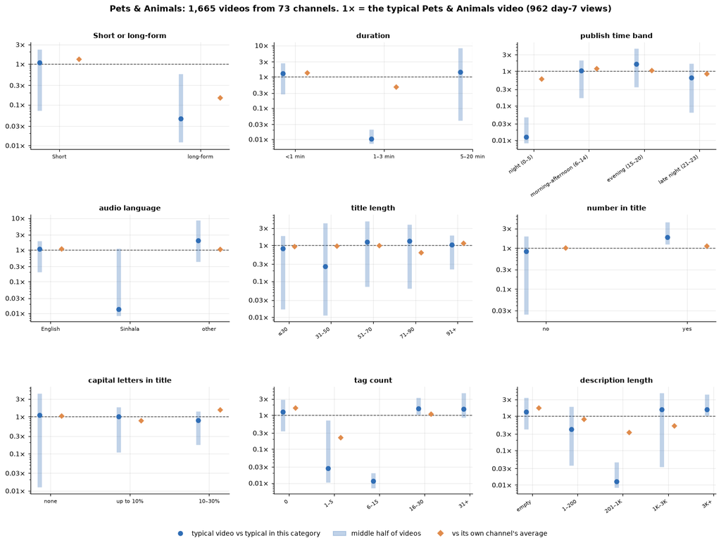

| input | best (vs typical in category) | worst | best vs own channel | worst vs own channel | own-channel gap |
| --- | --- | --- | --- | --- | --- |
| Short or long-form | Short (1.08×) | long-form (0.05×) | Short (1.31×) | long-form (0.15×) | 8.84× |
| duration | <1 min (1.30×) | 1–3 min (0.01×) | <1 min (1.32×) | 1–3 min (0.47×) | 2.82× |
| publish time band | evening (15–20) (1.61×) | night (0–5) (0.01×) | morning–afternoon (6–14) (1.19×) | night (0–5) (0.59×) | 2.01× |
| audio language | other (1.96×) | Sinhala (0.01×) | English (1.06×) | other (1.03×) | 1.03× |
| title length | 71–90 (1.31×) | 31–50 (0.26×) | 91+ (1.14×) | ≤30 (0.92×) | 1.24× |
| number in title | yes (1.86×) | no (0.83×) | yes (1.13×) | no (0.99×) | 1.13× |
| capital letters in title | none (1.12×) | 10–30% (0.79×) | 10–30% (1.53×) | up to 10% (0.77×) | 1.97× |
| tag count | 16–30 (1.58×) | 6–15 (0.01×) | 0 (1.61×) | 1–5 (0.22×) | 7.45× |
| description length | 3K+ (1.56×) | 201–1K (0.01×) | empty (1.67×) | 201–1K (0.34×) | 4.99× |

**Pets & Animals.** Almost all Shorts. The few long-form videos do very badly (0.15× the channel's average). Posting in the day is best, at night worst. Several gaps here are large because there are few long-form videos; treat the exact numbers with care.

### Film & Animation

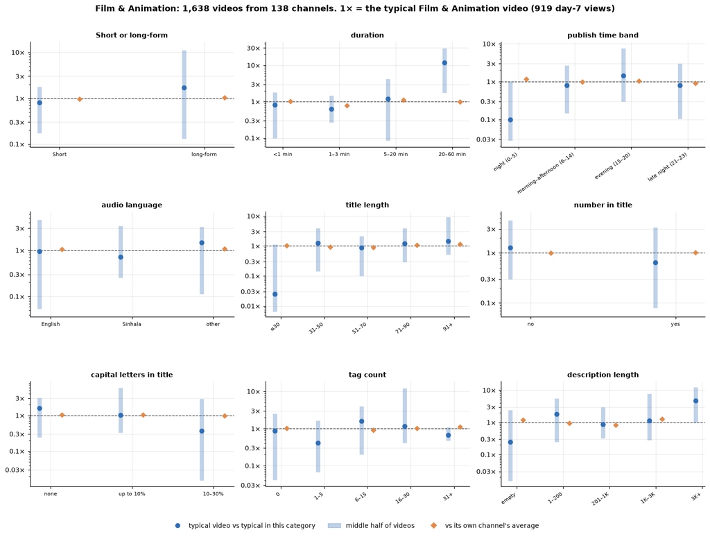

| input | best (vs typical in category) | worst | best vs own channel | worst vs own channel | own-channel gap |
| --- | --- | --- | --- | --- | --- |
| Short or long-form | long-form (1.70×) | Short (0.81×) | long-form (1.02×) | Short (0.96×) | 1.07× |
| duration | 20–60 min (12×) | 1–3 min (0.63×) | 5–20 min (1.10×) | 1–3 min (0.77×) | 1.42× |
| publish time band | evening (15–20) (1.43×) | night (0–5) (0.10×) | evening (15–20) (1.03×) | late night (21–23) (0.89×) | 1.15× |
| audio language | other (1.47×) | Sinhala (0.71×) | too few channels |  |  |
| title length | 91+ (1.45×) | ≤30 (0.03×) | 91+ (1.13×) | 51–70 (0.89×) | 1.27× |
| number in title | no (1.26×) | yes (0.64×) | yes (1.00×) | no (0.98×) | 1.02× |
| capital letters in title | none (1.58×) | 10–30% (0.37×) | up to 10% (1.00×) | 10–30% (0.97×) | 1.03× |
| tag count | 6–15 (1.58×) | 1–5 (0.41×) | 0 (1.02×) | 16–30 (1.00×) | 1.02× |
| description length | 1–200 (1.79×) | empty (0.25×) | 1K–3K (1.24×) | 201–1K (0.82×) | 1.52× |

**Film & Animation.** Within a channel, almost nothing makes a difference. Only a longer description and 5 to 20 minute videos help slightly.

### Science & Technology

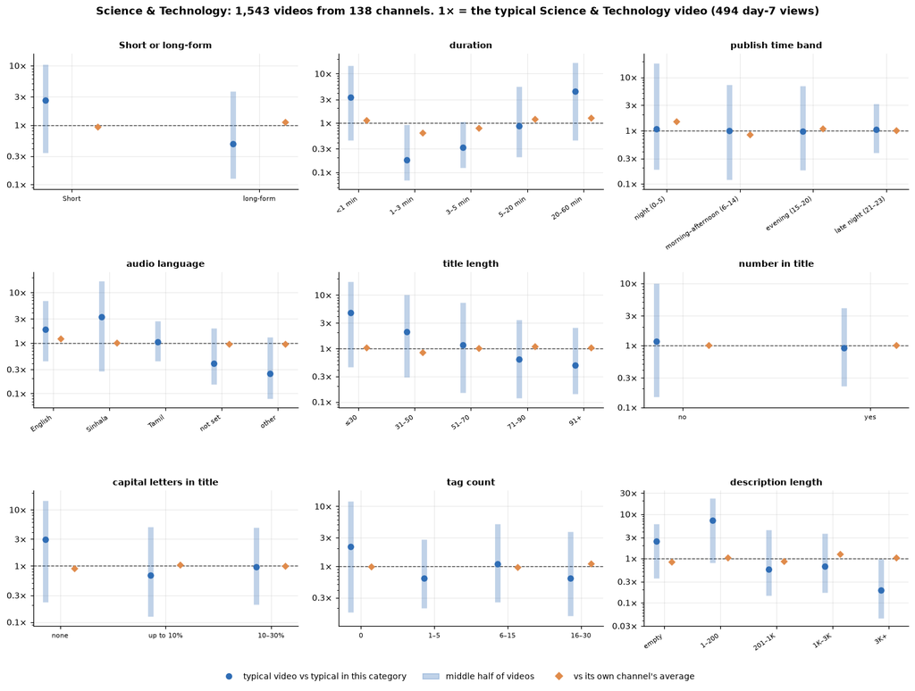

| input | best (vs typical in category) | worst | best vs own channel | worst vs own channel | own-channel gap |
| --- | --- | --- | --- | --- | --- |
| Short or long-form | Short (2.6×) | long-form (0.48×) | long-form (1.11×) | Short (0.93×) | 1.20× |
| duration | <1 min (3.3×) | 1–3 min (0.18×) | 5–20 min (1.18×) | 1–3 min (0.62×) | 1.89× |
| publish time band | late night (21–23) (1.04×) | evening (15–20) (0.97×) | evening (15–20) (1.07×) | morning–afternoon (6–14) (0.83×) | 1.29× |
| audio language | Sinhala (3.3×) | other (0.25×) | too few channels |  |  |
| title length | ≤30 (4.6×) | 91+ (0.49×) | 71–90 (1.09×) | 31–50 (0.83×) | 1.31× |
| number in title | no (1.16×) | yes (0.90×) | no (0.99×) | yes (0.99×) | 1.00× |
| capital letters in title | none (2.9×) | up to 10% (0.68×) | up to 10% (1.04×) | none (0.89×) | 1.17× |
| tag count | 0 (2.1×) | 16–30 (0.63×) | 16–30 (1.10×) | 6–15 (0.95×) | 1.16× |
| description length | 1–200 (7.2×) | 3K+ (0.19×) | 1K–3K (1.25×) | empty (0.82×) | 1.52× |

**Science & Technology.** Within a channel, **long-form does slightly better than Shorts** (1.1× against 0.9×), unlike most categories. 5 to 20 minute videos and a 1K to 3K character description help a little; the morning is the weakest time.

## Raw ranking against the own-channel ranking

Most channels post in one category only, so the own-channel comparison uses just the channels that post in two or more. For them it asks: is a video in this category better or worse than the channel's usual?

188 of 2,293 channels post in two or more categories.

|  | videos | × typical | raw rank | × own channel | videos in the own-channel view | channels | own-channel rank |
| --- | --- | --- | --- | --- | --- | --- | --- |
| Comedy | 1,735 | 4.7× | 1 | 1.11× | 174 | 14 | 3 |
| Entertainment | 9,582 | 3.3× | 2 | 0.88× | 1,935 | 75 | 13 |
| People & Blogs | 4,296 | 1.93× | 3 | 0.98× | 2,507 | 47 | 8 |
| Autos & Vehicles | 1,876 | 1.03× | 4 | 1.08× | 105 | 14 | 4 |
| Sports | 1,875 | 0.94× | 5 | 0.93× | 251 | 15 | 10 |
| Music | 5,512 | 0.92× | 6 | 1.15× | 244 | 24 | 2 |
| News & Politics | 23,885 | 0.89× | 7 | 6.3× | 157 | 11 | 1 |
| Pets & Animals | 1,665 | 0.80× | 8 | 0.87× | 141 | 19 | 14 |
| Education | 10,794 | 0.77× | 9 | 1.05× | 771 | 49 | 5 |
| Film & Animation | 1,638 | 0.77× | 10 | 0.93× | 209 | 21 | 11 |
| Travel & Events | 6,337 | 0.69× | 11 | 0.99× | 936 | 46 | 7 |
| Gaming | 3,772 | 0.47× | 12 | 1.00× | 391 | 26 | 6 |
| Science & Technology | 1,543 | 0.41× | 13 | 0.92× | 199 | 19 | 12 |
| Howto & Style | 2,311 | 0.19× | 14 | 0.98× | 277 | 24 | 9 |
| Other | 578 | 0.05× | 15 |  | 85 | 4 | <NA> |

**What this shows.** Only 188 channels post in more than one category, so the own-channel column is based on small numbers and should be read as a hint. It still flips the picture. **News & Politics** ranks 7th raw but 1st when a channel that usually posts something else posts news (6.3×, 11 channels). **Entertainment** falls from 2nd to 13th. A category's raw rank says more about its channels than about the content.

## Category by channel size (median day-7 views)

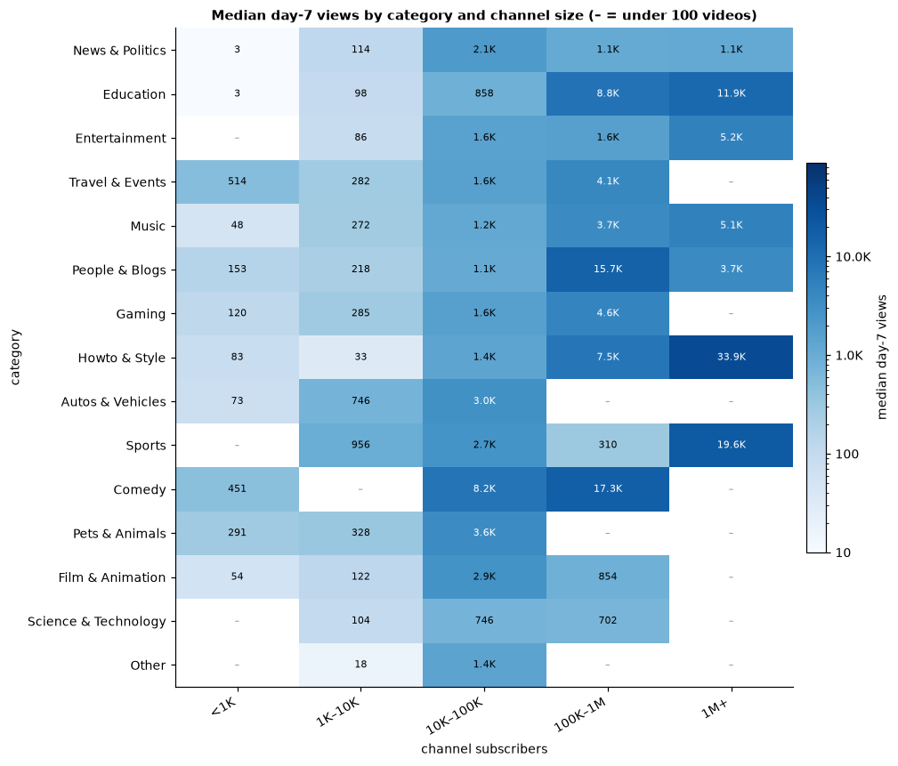

**What this shows.** Within the same channel size, categories are much closer than the raw ranking suggests. For example, Education is near the bottom raw, but at 100K+ subscribers it is one of the best (8.8K to 11.9K). Howto & Style is the worst raw category, yet 1M+ Howto channels get the highest median in the grid. Channel size explains most of what looks like a category effect.

## What a creator can change, category by category

Each grid compares videos with their **own channel's usual** views, so channel size is removed. **Blue** is better than usual, **red** worse, white about the same. Cells with fewer than 100 videos are left blank.

### Short or long-form

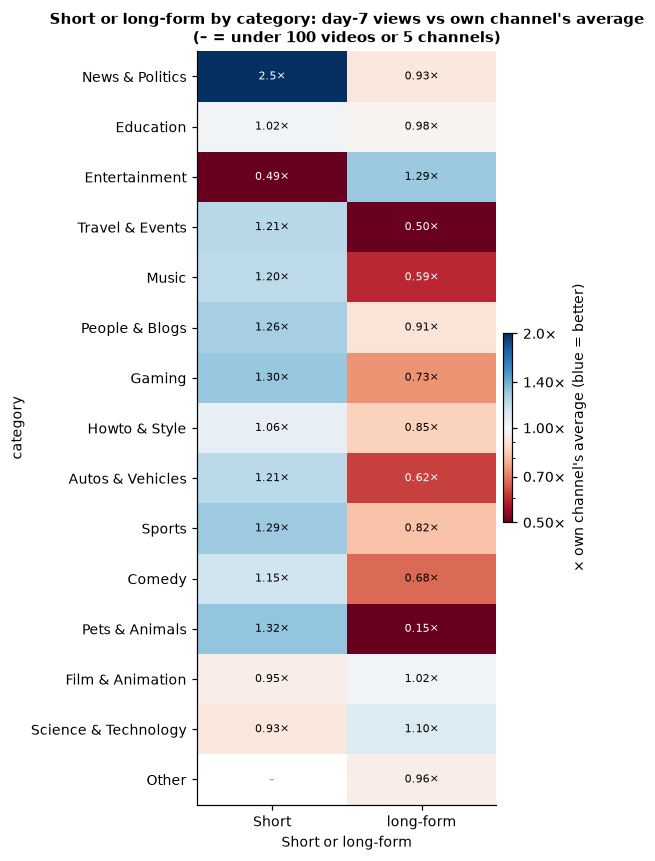

**What this shows.** Compared with their own channel, Shorts beat long-form in most categories. The exceptions are **Entertainment**, where long-form wins clearly (1.29× against 0.49×), Film & Animation and Science & Technology, where long-form is slightly ahead, and Education, where it makes no difference. News channels' occasional Shorts do very well (2.5×).

### duration

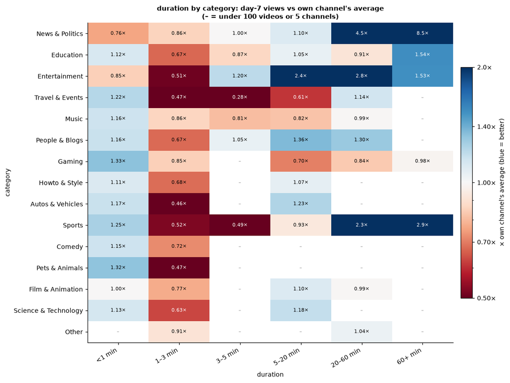

### publish time band

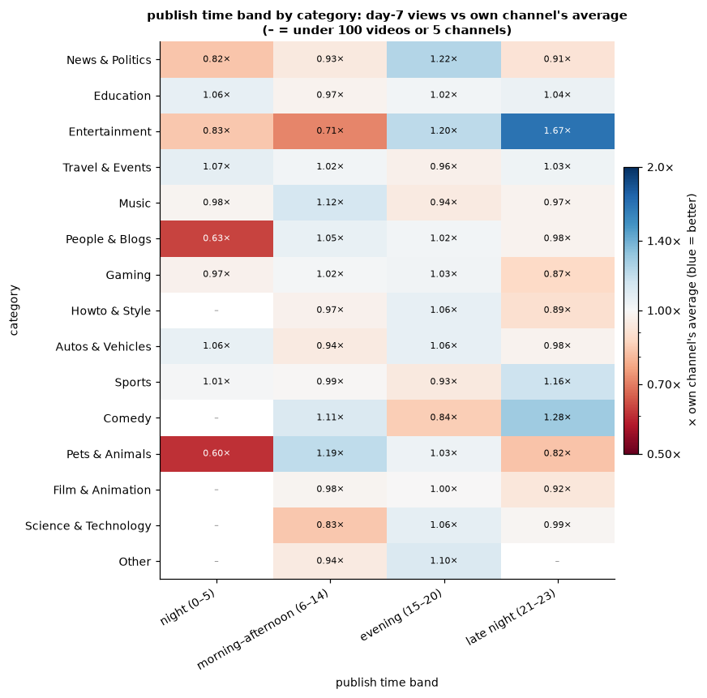

**What this shows.** Time of day matters in only a few categories: Entertainment and Comedy do best late at night (21:00 to 23:00), News in the evening, People & Blogs and Pets in the day. In the rest it makes no clear difference.

### weekend

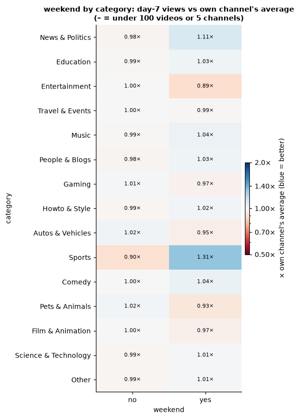

**What this shows.** Weekend against weekday makes little difference in most categories, which agrees with section 7. **Sports** is the exception: weekend videos get about 1.3× the channel's average, when matches are played.

### audio language

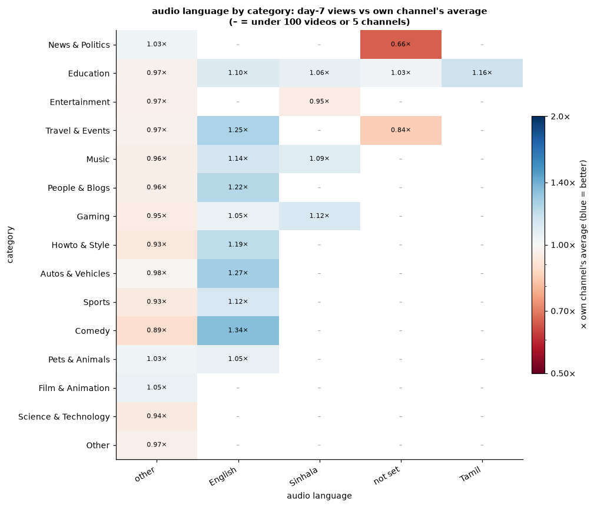

**What this shows.** Many cells are blank because few channels in a category post in two languages. Where they do, English videos usually beat the channel's average (1.1× to 1.3×), and "other" languages sit slightly below.

### number in title

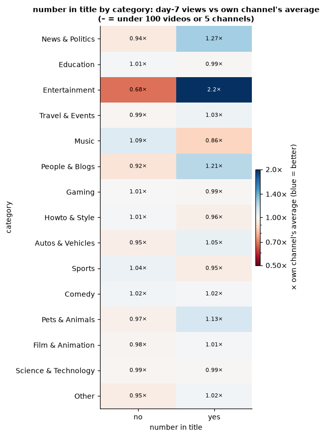

**What this shows.** A number in the title helps most in **Entertainment** (2.2×, often episode numbers), News & Politics and People & Blogs (about 1.2×). It makes little difference elsewhere and slightly hurts in Music.

### capital letters in title

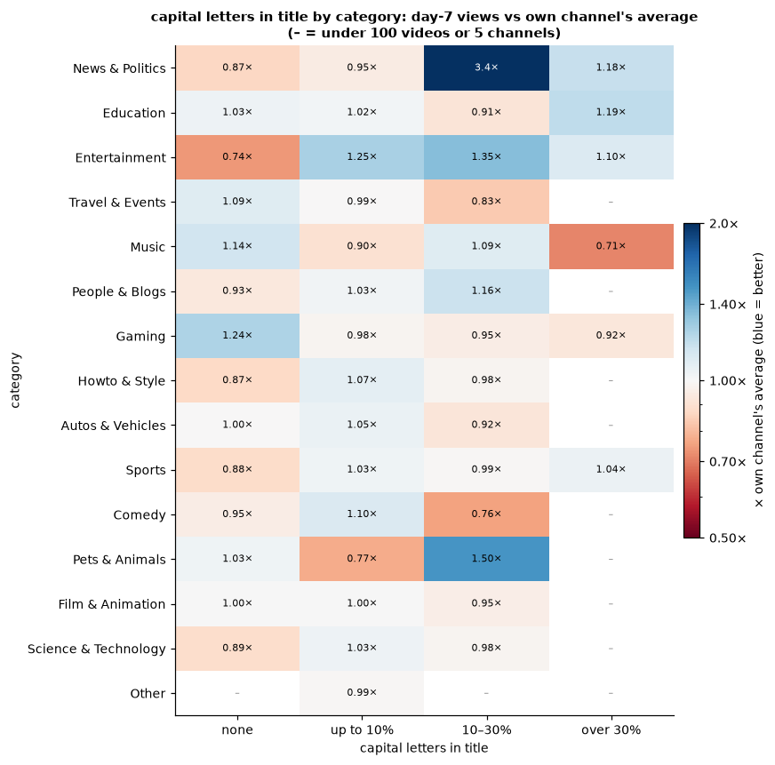

**What this shows.** Some capitals help in News and Entertainment; in Music, Gaming and Travel, titles without capitals do best.

### title length

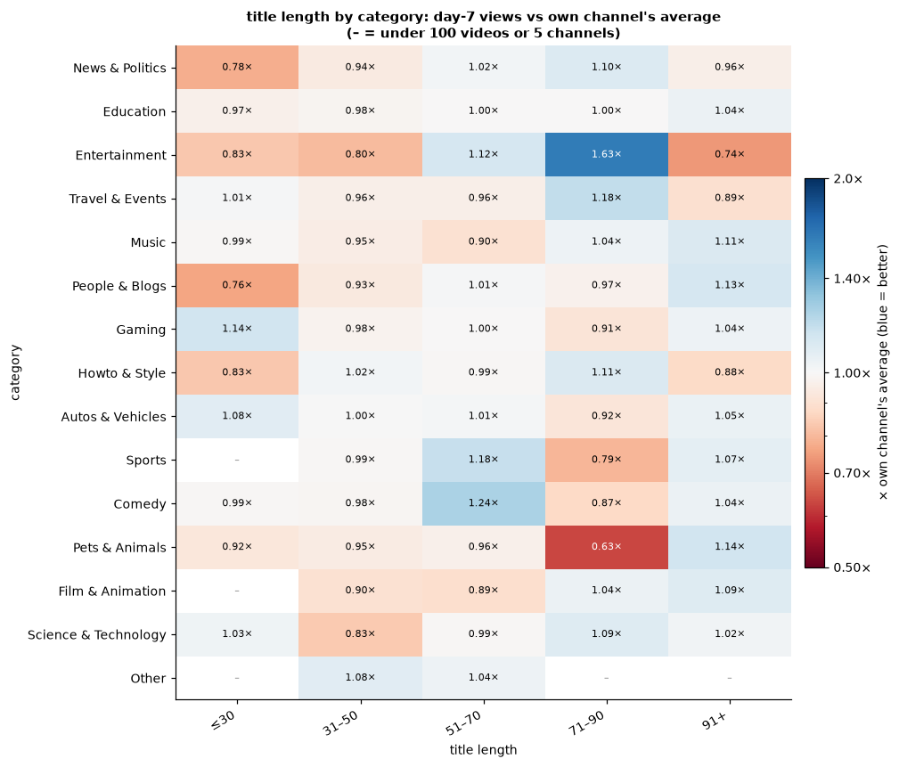

**What this shows.** Title length makes little difference in most categories. Entertainment is the exception, where 71 to 90 characters does best (1.6×).

### tag count

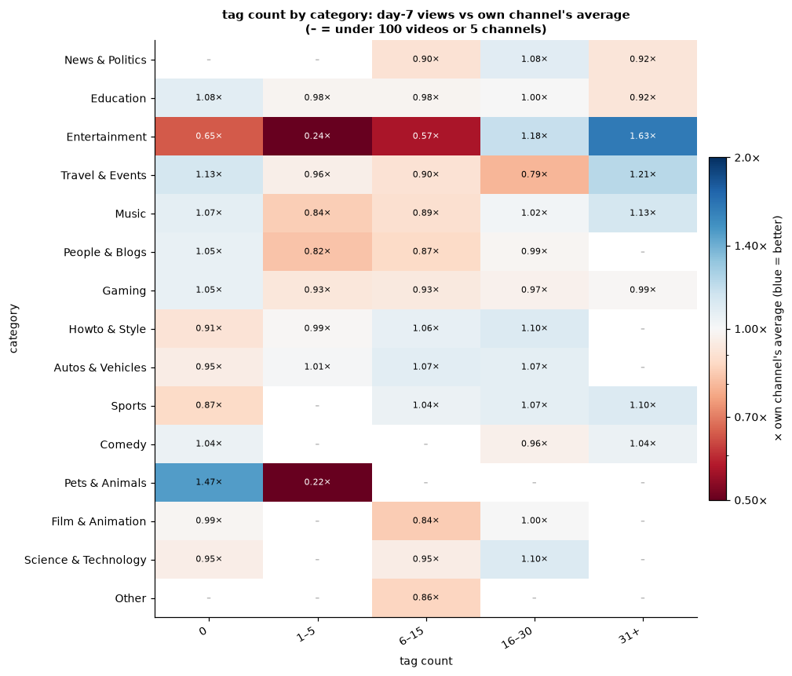

**What this shows.** Many tags (31+) help in Entertainment (1.6×) and a little in Travel, Music and Sports. Very few tags (1 to 5) are the worst choice in Entertainment and Pets (about 0.2×) and below average in most others.

## One line per category

- **News & Politics**: format: Short best (2.5×), long-form worst (0.93×); length: 60+ min best (8.5×), <1 min worst (0.76×); time: evening (15–20) best (1.22×), night (0–5) worst (0.82×); title capitals: 10–30% best (3.4×), none worst (0.87×); tags: no clear difference

- **Education**: format: no clear difference; length: 60+ min best (1.54×), 1–3 min worst (0.67×); time: no clear difference; title capitals: over 30% best (1.19×), 10–30% worst (0.91×); tags: no clear difference

- **Entertainment**: format: long-form best (1.29×), Short worst (0.49×); length: 20–60 min best (2.8×), 1–3 min worst (0.51×); time: late night (21–23) best (1.67×), morning–afternoon (6–14) worst (0.71×); title capitals: 10–30% best (1.35×), none worst (0.74×); tags: 31+ best (1.63×), 1–5 worst (0.24×)

- **Travel & Events**: format: Short best (1.21×), long-form worst (0.50×); length: <1 min best (1.22×), 3–5 min worst (0.28×); time: no clear difference; title capitals: none best (1.09×), 10–30% worst (0.83×); tags: 31+ best (1.21×), 16–30 worst (0.79×)

- **Music**: format: Short best (1.20×), long-form worst (0.59×); length: <1 min best (1.16×), 3–5 min worst (0.81×); time: no clear difference; title capitals: none best (1.14×), over 30% worst (0.71×); tags: 31+ best (1.13×), 1–5 worst (0.84×)

- **People & Blogs**: format: Short best (1.26×), long-form worst (0.91×); length: 5–20 min best (1.36×), 1–3 min worst (0.67×); time: morning–afternoon (6–14) best (1.05×), night (0–5) worst (0.63×); title capitals: 10–30% best (1.16×), none worst (0.93×); tags: 0 best (1.05×), 1–5 worst (0.82×)

- **Gaming**: format: Short best (1.30×), long-form worst (0.73×); length: <1 min best (1.33×), 5–20 min worst (0.70×); time: no clear difference; title capitals: none best (1.24×), over 30% worst (0.92×); tags: no clear difference

- **Howto & Style**: format: Short best (1.06×), long-form worst (0.85×); length: <1 min best (1.11×), 1–3 min worst (0.68×); time: no clear difference; title capitals: up to 10% best (1.07×), none worst (0.87×); tags: 16–30 best (1.10×), 0 worst (0.91×)

- **Autos & Vehicles**: format: Short best (1.21×), long-form worst (0.62×); length: 5–20 min best (1.23×), 1–3 min worst (0.46×); time: no clear difference; title capitals: no clear difference; tags: no clear difference

- **Sports**: format: Short best (1.29×), long-form worst (0.82×); length: 60+ min best (2.9×), 3–5 min worst (0.49×); time: late night (21–23) best (1.16×), evening (15–20) worst (0.93×); title capitals: no clear difference; tags: 31+ best (1.10×), 0 worst (0.87×)

- **Comedy**: format: Short best (1.15×), long-form worst (0.68×); length: <1 min best (1.15×), 1–3 min worst (0.72×); time: late night (21–23) best (1.28×), evening (15–20) worst (0.84×); title capitals: up to 10% best (1.10×), 10–30% worst (0.76×); tags: no clear difference

- **Pets & Animals**: format: Short best (1.32×), long-form worst (0.15×); length: <1 min best (1.32×), 1–3 min worst (0.47×); time: morning–afternoon (6–14) best (1.19×), night (0–5) worst (0.60×); title capitals: 10–30% best (1.50×), up to 10% worst (0.77×); tags: 0 best (1.47×), 1–5 worst (0.22×)

- **Film & Animation**: format: no clear difference; length: 5–20 min best (1.10×), 1–3 min worst (0.77×); time: no clear difference; title capitals: no clear difference; tags: no clear difference

- **Science & Technology**: format: no clear difference; length: 5–20 min best (1.18×), 1–3 min worst (0.63×); time: evening (15–20) best (1.06×), morning–afternoon (6–14) worst (0.83×); title capitals: no clear difference; tags: no clear difference

- **Other**: length: no clear difference; time: no clear difference

**How to use these lines.** Each is a draft guideline for creators in that category, based on how their videos did against their own channel. "No clear difference" means the best and worst options were within 1.2× of each other.

Treat the extreme numbers with care. In News & Politics most channels post long-form clips, so its rare Shorts, hour-long streams and capitalised titles come from a small set of videos, which is why they show 2.5× to 8.5×.

# 11. Growth from day 7 to day 30

How many extra views a video gains between day 7 and day 30, on the videos with all four labels. 20% means day-30 views are 1.2 times day-7 views.

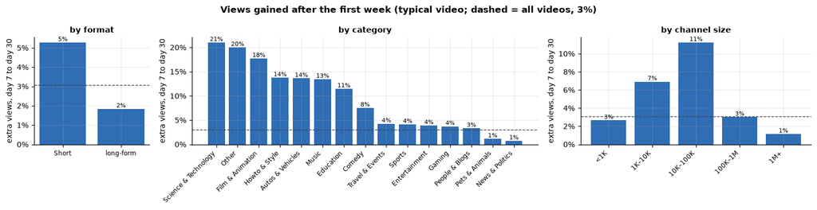

**What this shows.** How much a video keeps growing after its first week.

- **Science & Technology, Film & Animation, Howto & Style, Autos and Music** gain 13 to 21% more after day 7. These are searched for later.
- **News & Politics and Pets & Animals** gain about 1%. They are watched almost entirely in the first week.
- **Channels of 10K to 100K subscribers** keep growing the most (11%); very large channels the least (1%).
- Shorts gain slightly more than long-form (5% against 2%).

So the day-30 forecast matters most for evergreen categories and mid-size channels; for news it is almost the same as day 7.

# 12. Where the data is thin

Number of videos with a day-7 label for each category and channel size. A model learns little where a cell is small, so forecasts there deserve less trust.

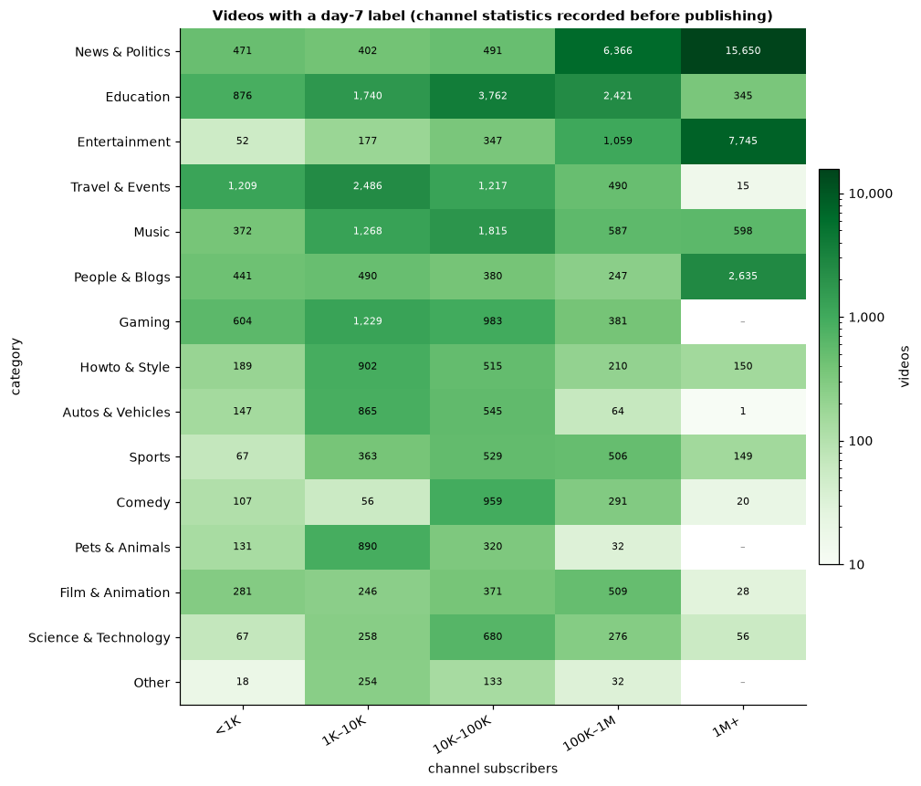

**16** of 75 cells have fewer than 100 videos.

# 13. Does the data change over time?

Typical day-7 views by the week a video was published. The model is trained on earlier weeks and tested on later ones, so a steady line is what we want.

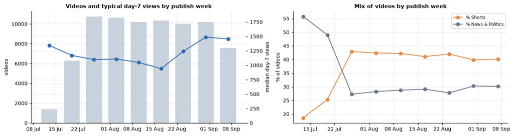

|  | videos | median day-7 views | % Shorts | % News & Politics |
| --- | --- | --- | --- | --- |
| week of 13 Jul | 1,373 | 1.3K | 19% | 56% |
| week of 20 Jul | 6,319 | 1.2K | 25% | 49% |
| week of 27 Jul | 10,739 | 1.1K | 43% | 27% |
| week of 03 Aug | 10,637 | 1.1K | 42% | 28% |
| week of 10 Aug | 10,212 | 1.0K | 42% | 29% |
| week of 17 Aug | 10,352 | 941 | 41% | 29% |
| week of 24 Aug | 10,023 | 1.2K | 42% | 28% |
| week of 31 Aug | 10,183 | 1.5K | 40% | 30% |
| week of 07 Sep | 7,561 | 1.5K | 40% | 30% |

**What this shows.** From late July on, the mix is steady: about 40% Shorts and 30% News every week, and 10,000 labelled videos a week. The first two weeks differ (more News, fewer Shorts) because only some channels were tracked then. Typical day-7 views dip in mid-August and rise at the start of September, from about 950 to 1,500. A model tested on the latest weeks will therefore see somewhat higher views than it was trained on.

# 14. What the most-viewed videos look like

The top 1% of videos by day-7 views, compared with all videos.

Top 1% = at least **340.3K** day-7 views (774 videos from 88 channels). The top 10 channels account for **64%** of them.

**By channel size** (% of videos)

| subscribers | all videos | top 1% |
| --- | --- | --- |
| 1M+ | 35% | 64% |
| 100K–1M | 17% | 19% |
| 10K–100K | 17% | 8% |
| recorded after publishing | 9% | 8% |
| 1K–10K | 15% | 1% |
| <1K | 7% | 0% |

**By format** (% of videos)

| Short or long-form | all videos | top 1% |
| --- | --- | --- |
| long-form | 60% | 50% |
| Short | 40% | 50% |

**By category** (% of videos)

| category_name | all videos | top 1% |
| --- | --- | --- |
| Entertainment | 12% | 50% |
| Education | 14% | 14% |
| Comedy | 2% | 13% |
| People & Blogs | 6% | 5% |
| News & Politics | 31% | 4% |
| Music | 7% | 3% |
| Howto & Style | 3% | 3% |
| Sports | 2% | 3% |

**By duration** (% of videos)

| duration | all videos | top 1% |
| --- | --- | --- |
| <1 min | 39% | 45% |
| 20–60 min | 8% | 29% |
| 5–20 min | 15% | 16% |
| 1–3 min | 26% | 7% |
| 3–5 min | 9% | 1% |
| 60+ min | 3% | 1% |

**What this shows.** The most-viewed 1% of videos come from a narrow group: 774 videos from 88 channels, and the top 10 channels produce 64% of them. 83% come from channels over 100K subscribers. **Entertainment is half of them** despite being 12% of videos; **News & Politics is 31% of videos but only 4%** of the top. Shorts are slightly over-represented (50% against 40%), and so are 20 to 60 minute videos (29% against 8%). Big errors on these few videos will dominate any average error figure, so median-based error should be reported alongside it.

# 15. Inputs that repeat each other

When two inputs carry the same information, the model only needs one. **Rank agreement** runs from 0 (unrelated) to 1 (always in the same order).

| pair | how related | what to do |
| --- | --- | --- |
| title length vs title word count | rank agreement 0.83 | keep one |
| weekend vs publish weekday | weekend is Sat or Sun: fully decided by weekday | keep one |
| publish time band vs publish hour | the band is a grouping of the hour | keep one |
| hour sin/cos vs publish hour | the same hour written as a point on a circle | encoding, not a new input |
| Short vs duration | 0 Shorts over 3 min; 8,075 videos of 60 s or l... | both needed: shape adds what length cannot |
| audio language vs default language | agree on 58% of videos | the API sends one, mapped from the other |
| subscribers vs channel average views | rank agreement 0.71 | related, both useful |
| channel video count vs uploads per day | rank agreement 0.94 | related |
| tag count vs description length | rank agreement 0.44 | mostly separate |

**What this shows.** Title length and word count, weekday and weekend, and hour and time band each carry the same information: keep one of each pair. Short and duration are **not** duplicates: 8,000 videos of a minute or less are not Shorts, so the shape adds something length cannot. Channel video count and uploads per day agree almost completely (0.94), so one of them is enough.

# 16. What the forecast actually receives

An input only helps if the app can supply it when a creator asks for a forecast. This is what `prediction_api/app/feature_builder.py` sends today.

| input | where it comes from | status today |
| --- | --- | --- |
| category, duration | on the form | sent |
| audio language | on the form | sent, mapped to en / si / ta |
| publish day and hour | on the form, optional | sent as weekend yes/no and a four-band time |
| subscribers, video count, channel age, average views | looked up from the channel | sent |
| Short or long-form | not asked | always missing: the form needs the field |
| YouTube topic | available from the same channel lookup | always missing: needs fetching |
| title | typed on the form | used for tone advice only, not the forecast |
| tags, description | not asked | not used |
| HD or SD, captions, made for kids | not asked | not used (nearly constant anyway) |

**What this shows.** Three strong inputs are available but not used:

- **YouTube topic** explains 10% of views and comes from the same channel lookup the API already makes.
- **Short or long-form** needs one form field.
- **Title-based inputs** can be worked out from the title the form already collects.

Tags and description would need new form fields.

# 17. Summary: every input

Day-7 numbers use all videos with a day-7 label. The four "explains" columns use the same videos at every horizon (those with all four labels), so they can be compared across time.

| input | section | source at forecast time | explains (day 7) | gap vs own channel | explains d7 (same videos) | explains d14 (same videos) | explains d21 (same videos) | explains d30 (same videos) | verdict | why | strength |
| --- | --- | --- | --- | --- | --- | --- | --- | --- | --- | --- | --- |
| channel average views per video | channel | looked up from the channel | 38.1% |  | 36.9% | 36.9% | 36.9% | 36.8% | keep | explains 38.1% of day-7 views | strong |
| subscribers | channel | looked up from the channel | 22.5% |  | 18.6% | 17.9% | 17.4% | 17.1% | keep | explains 22.5% of day-7 views | strong |
| YouTube topic | channel | looked up from the channel (not sent yet) | 10.3% |  | 9.3% | 9.0% | 8.9% | 8.8% | keep, needs serving work | explains 10.3% of day-7 views; looked up from the channel (not sent yet) | strong |
| category | format | on the form | 9.1% |  | 8.4% | 8.3% | 8.3% | 8.4% | keep | explains 9.1% of day-7 views | strong |
| channel video count | channel | looked up from the channel | 4.5% |  | 3.4% | 2.9% | 2.6% | 2.4% | keep | explains 4.5% of day-7 views | moderate |
| title script | language | worked out from the title (not sent yet) | 4.0% | 1.05× | 3.2% | 3.0% | 2.9% | 2.8% | keep, needs serving work | 1.05× gap against own channel, 1.64× for 1M+ channels; worked out from the title (not sent yet) | only for 1M+ channels |
| channel uploads per day | channel | worked out from the channel | 3.5% |  | 2.8% | 2.4% | 2.2% | 2.0% | keep | explains 3.5% of day-7 views | moderate |
| audio language | language | on the form | 3.4% | 1.32× | 2.7% | 2.5% | 2.4% | 2.3% | keep | 1.32× gap against own channel | moderate |
| tag count | text | not on the form | 3.0% | 1.50× | 2.3% | 2.2% | 2.1% | 2.1% | keep, needs serving work | 1.50× gap against own channel; not on the form | strong |
| channel age | channel | looked up from the channel | 2.5% |  | 1.8% | 1.6% | 1.6% | 1.5% | keep | explains 2.5% of day-7 views | moderate |
| default language | language | on the form (mapped from audio language) | 1.9% | 1.20× | 1.5% | 1.3% | 1.2% | 1.1% | keep | 1.20× gap against own channel | moderate |
| publish hour | timing | on the form (optional) | 1.7% | 1.94× | 1.7% | 1.8% | 1.9% | 1.9% | keep | 1.94× gap against own channel | strong |
| duration | format | on the form | 1.6% | 2.59× | 1.3% | 1.4% | 1.5% | 1.6% | keep | 2.59× gap against own channel | strong |
| capital letters in title | title | worked out from the title (not sent yet) | 1.2% | 1.31× | 1.0% | 0.9% | 0.8% | 0.8% | keep, needs serving work | 1.31× gap against own channel; worked out from the title (not sent yet) | moderate |
| title word count | title | worked out from the title (not sent yet) | 0.8% | 1.27× | 0.5% | 0.5% | 0.5% | 0.6% | keep, needs serving work | 1.27× gap against own channel; worked out from the title (not sent yet) | moderate |
| made for kids | format | not on the form | 0.7% |  | 0.5% | 0.5% | 0.4% | 0.4% | drop | almost every video has the same value (99%) |  |
| description length | text | not on the form | 0.7% | 1.30× | 0.6% | 0.6% | 0.7% | 0.7% | keep, needs serving work | 1.30× gap against own channel; not on the form | moderate |
| publish time band | timing | on the form (optional) | 0.6% | 1.20× | 0.7% | 0.7% | 0.7% | 0.8% | keep | 1.20× gap against own channel | moderate |
| title length | title | worked out from the title (not sent yet) | 0.6% | 1.18× | 0.5% | 0.5% | 0.5% | 0.5% | keep, needs serving work | 1.18× gap against own channel, 1.53× for 1M+ channels; worked out from the title (not sent yet) | only for 1M+ channels |
| exclamation mark in title | title | worked out from the title (not sent yet) | 0.4% | 1.14× | 0.5% | 0.5% | 0.5% | 0.5% | keep, needs serving work | 1.14× gap against own channel, 1.47× for 1M+ channels; worked out from the title (not sent yet) | only for 1M+ channels |
| HD or SD | format | not on the form | 0.3% | 1.10× | 0.4% | 0.4% | 0.4% | 0.4% | drop | almost every video has the same value (96%) |  |
| Short or long-form | format | not sent yet (form needs the field) | 0.1% | 1.17× | 0.0% | 0.0% | 0.0% | 0.0% | keep, needs serving work | 1.17× gap against own channel, 1.97× for 1K–10K channels; not sent yet (form needs the field) | only for 1K–10K channels |
| publish weekday | timing | on the form (optional) | 0.1% | 1.15× | 0.1% | 0.1% | 0.1% | 0.1% | keep | 1.15× gap against own channel, 1.31× for <1K channels | only for <1K channels |
| question mark in title | title | worked out from the title (not sent yet) | 0.0% | 1.18× | 0.0% | 0.0% | 0.0% | 0.0% | keep, needs serving work | 1.18× gap against own channel, 1.38× for 1M+ channels; worked out from the title (not sent yet) | only for 1M+ channels |
| number in title | title | worked out from the title (not sent yet) | 0.0% | 1.29× | 0.0% | 0.0% | 0.0% | 0.0% | keep, needs serving work | 1.29× gap against own channel; worked out from the title (not sent yet) | moderate |
| captions | format | not on the form | 0.0% |  | 0.0% | 0.0% | 0.0% | 0.0% | drop | almost every video has the same value (100%) |  |
| channel country | channel | looked up from the channel | 0.0% |  | 0.0% | 0.0% | 0.0% | 0.0% | drop | almost every video has the same value (100%) |  |
| weekend | timing | on the form (optional) | 0.0% | 1.04× | 0.0% | 0.0% | 0.0% | 0.0% | drop | 1.04× gap against own channel (too small) |  |

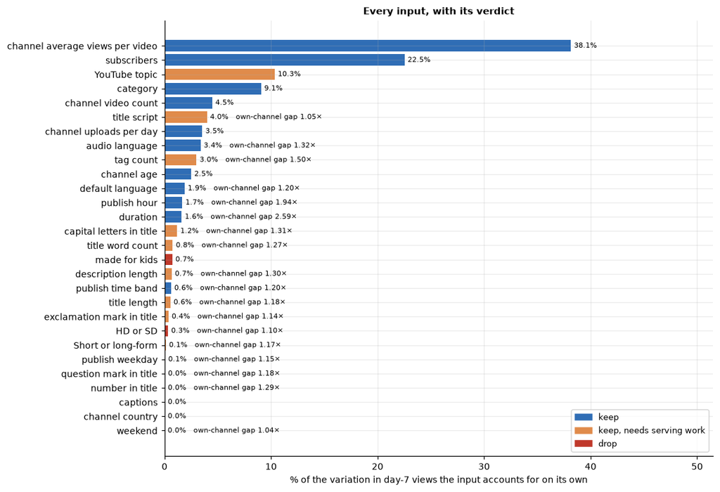

## In short

**Strongest inputs:** the channel's average views per video (38%), subscribers (23%), the channel's YouTube topic (10%) and category (9%). Within a channel, **duration** (2.6× gap between best and worst), **publish hour** (1.9×) and **tag count** (1.5×) matter most.

**Drop:** channel country, captions, made for kids, HD or SD (almost all videos the same), and weekend (no difference).

**Moderate:** audio language, number in title, capital letters, word count, description length, time band. **Weak or only for some channel sizes:** title script, title length, question and exclamation marks, weekday.

**Most important thing a creator controls:** Short or long-form, depending on channel size. For channels under 100K subscribers, Shorts get about 1.35× to 2× the channel's own long-form. For bigger channels they do not help.

**For the model and the app:**

1. Fetch the channel's YouTube topic at forecast time.
2. Add a Short or long-form field to the form.
3. Use the title the form already collects to work out title inputs.
4. Consider tags and description fields.
5. Send the exact publish hour rather than a four-band time.
6. Train on the same language mapping the API uses.

**Horizons.** Every input's effect is nearly the same at day 7, 14, 21 and 30 (same videos). The largest drift is subscribers, falling from 18.6% to 17.1%. One model design across horizons is reasonable; per-horizon differences come from growth (section 11), not from different inputs mattering.